Analyze nanopore data to see which phagemid lines are monomorphic

```r
library(tidyverse)
library(here)
library(fs)
library(furrr)
plan(multicore, workers = 3)
import::from(Biostrings, complement, reverseComplement, width, DNAString,
  DNAStringSet, readDNAStringSet, subseq,
  vmatchPDict, vcountPDict
)
import::from(DECIPHER, TrimDNA, AlignSeqs, OrientNucleotides, BrowseSeqs)
```

```r
seq_barcodes <- here('output', '2022-05-18-sequencing-barcodes',
  'sequencing-barcodes.csv') %>%
  read_csv %>%
  glimpse
```

```
## Rows: 96
## Columns: 15
## $ primer_1             <chr> "AGCTTCGGGCCTAACTAACTACT", "AGCTTCGGGCCTAAC…
## $ primer_1_length      <dbl> 23, 23, 23, 23, 23, 23, 23, 23, 23, 23, 23,…
## $ primer_2             <chr> "CGCTTTACGTTACGTCGAAAGC", "CGCTTTACGTTACGTC…
## $ primer_2_length      <dbl> 22, 22, 22, 22, 22, 22, 22, 22, 22, 22, 22,…
## $ primer_2_rc          <chr> "GCTTTCGACGTAACGTAAAGCG", "GCTTTCGACGTAACGT…
## $ probe                <chr> "AATCCGCCGGTCTTCGTGTTCAGCACAG", "AATCCGCCGG…
## $ probe_length         <dbl> 28, 28, 28, 28, 28, 28, 28, 28, 28, 28, 28,…
## $ spacer_1             <chr> "AGTC", "AGTC", "AGTC", "AGTC", "AGTC", "AG…
## $ spacer_2             <chr> "TGAC", "TGAC", "TGAC", "TGAC", "TGAC", "TG…
## $ spacer_3             <chr> "TCTA", "TCTA", "TCTA", "TCTA", "TCTA", "TC…
## $ ont_barcode_id       <chr> "BC01", "BC02", "BC03", "BC04", "BC05", "BC…
## $ ont_barcode_sequence <chr> "AAGAAAGTTGTCGGTGTCTTTGTG", "TCGATTCCGTTTGT…
## $ ont_barcode_length   <dbl> 24, 24, 24, 24, 24, 24, 24, 24, 24, 24, 24,…
## $ amplicon             <chr> "AGCTTCGGGCCTAACTAACTACTAGTCAAGAAAGTTGTCGGT…
## $ amplicon_length      <dbl> 109, 109, 109, 109, 109, 109, 109, 109, 109…
```

Forward and reverse primers for the sequencing barcodes

```r
fwd <- seq_barcodes %>% pull(primer_1) %>% unique
rev <- seq_barcodes %>% pull(primer_2) %>% unique
rev_rc <- rev %>% DNAString %>% reverseComplement %>% as.character
stopifnot(identical(length(fwd), 1L))
stopifnot(identical(length(rev), 1L))
```

The eBlock sequences that we ordered:

```r
eblocks <- here('analysis/2022-05-18-sequencing-barcodes',
  '2022-05-20-eblock-template-mm.csv') %>% read_csv
```

The Sanger sequences, for the three wells that were Sanger sequenced:

```r
sanger <- here('data/2022-06-06-quantification-plasmid-sanger-sequencing/30-712437346.fasta') %>%
  readDNAStringSet
```

# Improved pipeline - Combo approach

First trim by primers (try both orientations and pick best), then match.

1. Combine all sequences into a single DNAStringSet
2. Give a common orientation
3. check that this is the correct oreitnation for the quant barcodes; if not, RC it.
4. Trim using the primers
5. Do some QC - check stats of matches; check that see the spacer and probe sequences
6. For successfully trimmed seqs, match against barcodes
7. Use to assess single or multiple copies (with some confidence score, based on how many total reads passing QC
8. Of ones with single q-seq barcode, check that they have the correct qPCR #barcode
9. pick 25 with desired 5X5 design

Should think of some QC to do within each of these steps.

## Combine all sequences into a single DNAStringSet

this is the data that was demultiplexed on june 16

```r
fns <- here('data', '2022-06-16-quantification-plasmid-nanopore-sequencing',
  '220603anjResults/pass') %>%
  dir_ls(recurse = TRUE, glob = '*.fastq')

fns %>%
  str_subset('unclassified', negate = TRUE) %>%
  length
```

[output not shown]

```
#> reads <- readDNAStringSet(fns, format = 'fastq')
```

Trying to read all the files in with one call to readDNAStringSet leads to an error, I think because of too many open connections.

So instead read each folder in one by one, then join into one DNAStringSet

```r
dirs <- here('data', '2022-06-16-quantification-plasmid-nanopore-sequencing',
  '220603anjResults/pass') %>%
  dir_ls
  # here('data',
  # '2022-06-03-quantification-plasmid-nanopore-sequencing/reads') %>%
reads_list <- dirs %>%
  map(dir_ls, glob = '*.fastq') %>%
  map(readDNAStringSet, format = 'fastq')
reads_raw <- reads_list %>% reduce(c)
# Drop unclassified reads
reads <- reads_raw %>%
  {.[str_detect(names(.), 'unclassified', negate = TRUE)]}
```

Note, the indexing barcode is reported at the end of the read name.

```r
names(reads) %>% str_sub(start = - 14) %>% sample(3)
```

```
## [1] "barcode=bw_000" "barcode=bw_017" "barcode=bw_084"
```

## Orient all reads to a common reference orientation

First, let’s add a reference sequence that we can use to set the orientation.

TODO: Get the full phagemid reference, not just the eblock.

```r
ref <- eblocks %>% slice(1) %>% pull(sequence) %>%
  set_names('reference') %>%
  DNAStringSet
reads_with_ref <- c(ref, reads)
```

```r
reads_oriented <- OrientNucleotides(reads_with_ref, reference = 1, processors = 3)
```

```
##
##
## Time difference of 45.28 secs
```

TODO: concider the threshold and orientation settings

## Trim using the flanking sequence

```r
trim_pattern <- seq_barcodes %>%
  slice(1) %>%
  transmute(
    left = str_c(primer_1, spacer_1),
    right = str_c(spacer_2, probe),
  ) %>%
  unlist
```

```r
reads_oriented_trimmed <- TrimDNA(
  reads_oriented,
  trim_pattern['left'],
  trim_pattern['right'],
  minWidth = 20,
  type = 'sequences'
)
```

```
## Finding left pattern: 56.2% internal, 0% flanking
##
## Finding right pattern: 70.8% internal, 0% flanking
##
## Time difference of 3.51 secs
```

Does it seem to be working?

```r
probe_length <- seq_barcodes$probe_length %>% unique
ont_barcode_length <- seq_barcodes$ont_barcode_length %>% unique
expected_length <- ont_barcode_length
```

```r
width(reads_oriented) %>% summary
```

```
##    Min. 1st Qu.  Median    Mean 3rd Qu.    Max.
##     128    1921    1937    1826    1949    6729
```

```r
width(reads_oriented_trimmed) %>% summary
```

```
##    Min. 1st Qu.  Median    Mean 3rd Qu.    Max.
##    20.0    24.0   496.5   574.3   792.0  4798.0
```

```r
mean(width(reads_oriented_trimmed) == expected_length)
```

```
## [1] 0.3047675
```

```r
mean(width(reads_oriented_trimmed) < 100)
```

```
## [1] 0.4412746
```

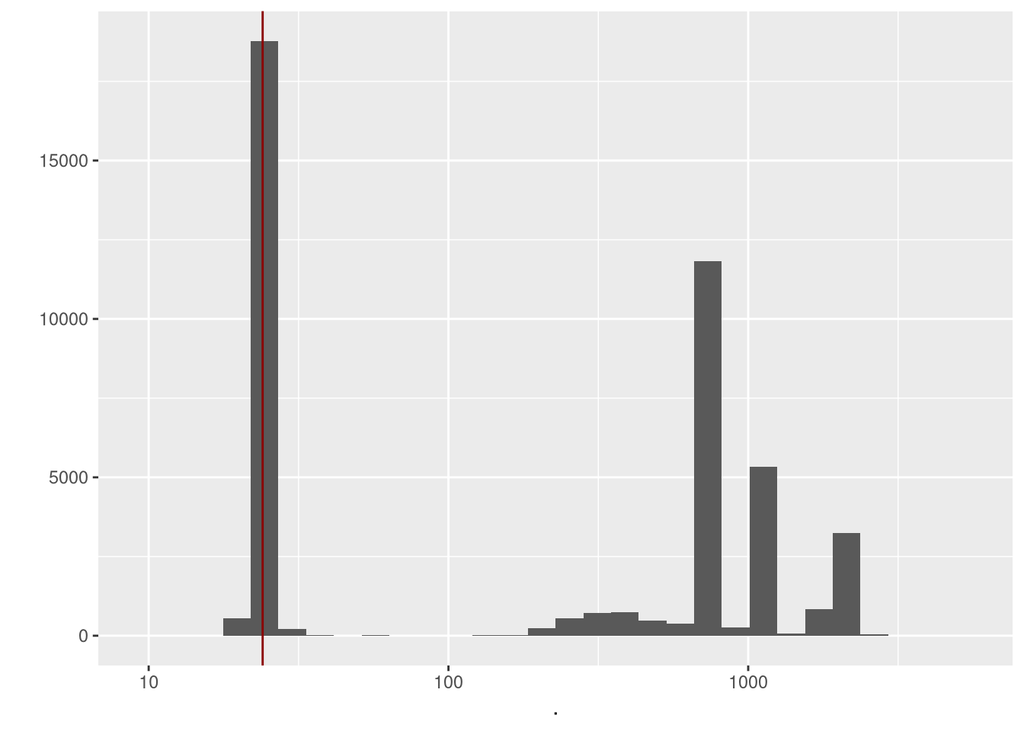

```r
width(reads_oriented_trimmed) %>% qplot +
  scale_x_log10() +
  expand_limits(x = 10) +
  geom_vline(xintercept = expected_length, color = 'darkred')
```

Looks like it worked; though most of the reads were not successfully trimmed at both primers.

TODO: consider TrimDNA options and how might increase trimming.

```r
reads_post <- reads_oriented_trimmed %>%
  {.[width(.) < 100]}
```

## Do some QC - check stats of matches; check that see the spacer and probe sequences

TODO

## For successfully trimmed seqs, match against barcodes

Get the ONT barcodes for matching,

```r
ont_barcodes <- seq_barcodes %>%
  select(ont_barcode_id, ont_barcode_sequence) %>%
  deframe %>%
  DNAStringSet
```

TODO: Check what the min edit distance is; use this to determine the max allowed edit distance for matching,

Do once I update Bioconductor and get DNABarcodes installed.

```r
xmat <- vcountPDict(ont_barcodes, reads_post,
  max.mismatch = 2, with.indels = TRUE)
rownames(xmat) <- names(ont_barcodes)
colnames(xmat) <- names(reads_post)
```

```
#> ~vcountPDict(pats, .x, with.indels = TRUE, max.mismatch = 2)),
```

possible improvements

- get the best match, up to sufficient closeness

Check that only one match per read:

```r
stopifnot( (colSums(xmat) %>% max) == 1 )
```

What fraction of reads match any barcode?

```r
(colSums(xmat) >= 1) %>% mean %>% round(2)
```

```
## [1] 0.87
```

- Turn into a dataframe with one row per read, filtered to matches
  - for qc, might want to track the total number of reads / non-matches
- extract the indexing barcode from the read name for well-matching

```r
x <- xmat %>%
  t %>%
  as_tibble(rownames = 'read_name') %>%
  pivot_longer(cols = starts_with('BC'), names_to = 'ont_barcode', values_to = 'match') %>%
  filter(match == 1) %>%
  select(-match) %>%
  mutate(
    index_barcode = str_extract(read_name, '(?<=barcode=bw_)[0-9]{3}$')
  )
```

```r
x %>%
  filter(read_name != 'reference') %>%
  with_groups(index_barcode, count, ont_barcode)
```

```
## # A tibble: 271 × 3
##    index_barcode ont_barcode     n
##    <chr>         <chr>       <int>
##  1 000           BC01            2
##  2 000           BC33          258
##  3 001           BC46          244
##  4 002           BC25            1
##  5 002           BC35            1
##  6 002           BC48          223
##  7 002           BC71            1
##  8 003           BC34            1
##  9 003           BC37            3
## 10 003           BC61          205
## # … with 261 more rows
```

Notice that there are many cases where a library has one or a few hits to a minority barcode. It is worth checking what is going on here.

Save the map from reads to barcodes:

```r
x %>%
  filter(read_name != 'reference') %>%
  write_csv('reads-matched-to-sequencing-barcode.csv')
```

## Use to assess if single or multiple barcodes present

With some confidence score, based on how many total reads passing QC?

```r
x_count <- x %>%
  filter(read_name != 'reference') %>%
  with_groups(index_barcode, count, ont_barcode) %>%
  with_groups(index_barcode, mutate,
    total = sum(n),
    frac = n / sum(n)
  )
```

```r
x_count %>%
  filter(frac > 0.05, n >= 4) %>%
  count(index_barcode) %>%
  pull(n) %>%
  table
```

```
## .
##  1  2  3
## 85  3  1
```

```r
x_count %>%
  filter(frac > 0.05, n >= 4) %>%
  add_count(index_barcode) %>%
  filter(nn>1)
```

```
## Storing counts in `nn`, as `n` already present in input
## ℹ Use `name = "new_name"` to pick a new name.
```

```
## # A tibble: 9 × 6
##   index_barcode ont_barcode     n total  frac    nn
##   <chr>         <chr>       <int> <int> <dbl> <int>
## 1 035           BC64           40    78 0.513     2
## 2 035           BC71           36    78 0.462     2
## 3 044           BC67           40   122 0.328     3
## 4 044           BC79           44   122 0.361     3
## 5 044           BC91           36   122 0.295     3
## 6 061           BC68           28   254 0.110     2
## 7 061           BC77          226   254 0.890     2
## 8 071           BC49           82   117 0.701     2
## 9 071           BC77           30   117 0.256     2
```

Question - how many secondary hits is acceptable?

### Check the three test wells

Helper function

```r
match_barcode <- function(subject, barcodes, ...) {
  xmat <- vcountPDict(barcodes, subject, ...)
  rownames(xmat) <- names(barcodes)
  colnames(xmat) <- names(subject)

  # ensure at most one match
  stopifnot( (colSums(xmat) %>% max) == 1 )

  # return vector with the name of the match or NA if none
  match <- xmat %>%
    {. == 1} %>%
    apply(2, which) %>%
    map_chr(~ifelse(length(.) == 0, NA, rownames(xmat)[.]))

  #> enframe(match, 'subject_name', 'barcode_name')
  match
}
```

```r
sanger_post <- sanger %>%
  c(ref, .) %>%
  OrientNucleotides(reference = 1, processors = 3) %>%
  TrimDNA(
    trim_pattern['left'],
    trim_pattern['right'],
    minWidth = 20,
    type = 'sequences'
  )
```

```
##
##
## Time difference of 0.02 secs
## Finding left pattern: 100% internal, 0% flanking
##
## Finding right pattern: 100% internal, 0% flanking
##
## Time difference of 0.02 secs
```

```r
sanger_match <- match_barcode(sanger_post, ont_barcodes,
  max.mismatch = 2, with.indels = TRUE
)
sanger_match %>% enframe %>% print
```

```
## # A tibble: 4 × 2
##   name                           value
##   <chr>                          <chr>
## 1 reference                      BC78
## 2 A1-barcode-check-BW334_F05.ab1 BC33
## 3 A2-barcode-check-BW334_G05.ab1 BC46
## 4 B1-barcode-check-BW334_F12.ab1 BC16
```

```r
x_count %>%
  filter(index_barcode %in% c('000', '008', '001')) %>%
  filter(frac > 0.05, n >= 4)
```

```
## # A tibble: 3 × 5
##   index_barcode ont_barcode     n total  frac
##   <chr>         <chr>       <int> <int> <dbl>
## 1 000           BC33          258   260 0.992
## 2 001           BC46          244   244 1
## 3 008           BC16          302   381 0.793
```

The Sanger sequences give the same barcode as the Nanopore sequences, as expected.

## Of ones with single q-seq barcode, check that they have the correct qPCR barcode

## pick 25 with desired 5X5 design

For this, we need to consider the qpcr barcodes as well. Can actually do this from the names,

```r
bc_map <- eblocks %>%
  select(-well_position) %>%
  separate(name, c('t', 'qpcr_barcode_set', 'qpcr_barcode_replicate',
      'seq_barcode_id'), remove = F) %>%
  mutate(
    qpcr_barcode_id = str_glue('{qpcr_barcode_set}_{qpcr_barcode_replicate}')
  ) %>%
  relocate(qpcr_barcode_id, .before = seq_barcode_id) %>%
  rename(eblock_sequence = sequence) %>%
  glimpse
```

```
## Rows: 96
## Columns: 7
## $ name                   <chr> "T1_QS2_010_BC78", "T1_QS2_018_BC14", "T1…
## $ t                      <chr> "T1", "T1", "T1", "T1", "T1", "T1", "T1",…
## $ qpcr_barcode_set       <chr> "QS2", "QS2", "QS2", "QS2", "QS2", "QS2",…
## $ qpcr_barcode_replicate <chr> "010", "018", "019", "018", "010", "004",…
## $ qpcr_barcode_id        <glue> "QS2_010", "QS2_018", "QS2_019", "QS2_01…
## $ seq_barcode_id         <chr> "BC78", "BC14", "BC85", "BC09", "BC73", "…
## $ eblock_sequence        <chr> "TCTCATTTTCGCCAAAAGTTGGCCATGTCAGCAGTGCTTT…
```

get the good wells, and join up the relevant bc info. Note, only some of the wells have minipreps available for transformations.

```r
wells <- x_count %>%
  mutate(
    index_barcode_int = as.integer(index_barcode),
    has_miniprep = index_barcode_int <= 67
  ) %>%
  with_groups(index_barcode, slice_max, order_by = n, n = 1) %>%
  rename(seq_barcode_id = ont_barcode) %>%
  left_join(bc_map, by = 'seq_barcode_id') %>%
  select(index_barcode, has_miniprep, qpcr_barcode_id, seq_barcode_id, n:frac, name,
    eblock_sequence)
```

Let’s see how many per qPCR barcode passing a basic minimum criterion,

```r
wells %>%
  filter(total >= 100, frac >= .90) %>%
  with_groups(qpcr_barcode_id, count)
```

```
## # A tibble: 5 × 2
##   qpcr_barcode_id     n
##   <glue>          <int>
## 1 QS2_004            18
## 2 QS2_007            17
## 3 QS2_010            19
## 4 QS2_018             7
## 5 QS2_019            15
```

what about with minipreps?

```r
wells %>%
  filter(total >= 100, frac >= .90, has_miniprep) %>%
  with_groups(qpcr_barcode_id, count)
```

```
## # A tibble: 5 × 2
##   qpcr_barcode_id     n
##   <glue>          <int>
## 1 QS2_004            17
## 2 QS2_007             9
## 3 QS2_010            15
## 4 QS2_018             7
## 5 QS2_019            10
```

Plenty are passing our condition. So we can be a bit more restrictive in the ones we pick.

Stricter criterion:

```r
wells %>%
  filter(total >= 100, frac >= .98, has_miniprep) %>%
  with_groups(qpcr_barcode_id, count)
```

```
## # A tibble: 5 × 2
##   qpcr_barcode_id     n
##   <glue>          <int>
## 1 QS2_004            17
## 2 QS2_007             7
## 3 QS2_010            12
## 4 QS2_018             5
## 5 QS2_019            10
```

Still getting at least 5 per, though with less wiggle room.

For wells passing the basic criterion, let’s make a ranked list:

```r
wells_ranked <- wells %>%
  filter(total >= 100, frac >= 0.9) %>%
  arrange(qpcr_barcode_id, desc(frac), seq_barcode_id) %>%
  with_groups(qpcr_barcode_id, mutate, rank = rank(-frac)) %>%
  relocate(rank, .before = eblock_sequence)
```

```r
wells_ranked %>%
  write_csv('ranked-wells.csv')
```

Similar, but only for wells with minipreps available:

```r
wells_ranked_miniprep <- wells %>%
  filter(total >= 100, frac >= 0.9, has_miniprep) %>%
  arrange(qpcr_barcode_id, desc(frac), seq_barcode_id) %>%
  with_groups(qpcr_barcode_id, mutate, rank = rank(-frac)) %>%
  relocate(rank, .before = eblock_sequence)
```

```r
wells_ranked_miniprep %>%
  write_csv('ranked-wells-with-minipreps.csv')
```